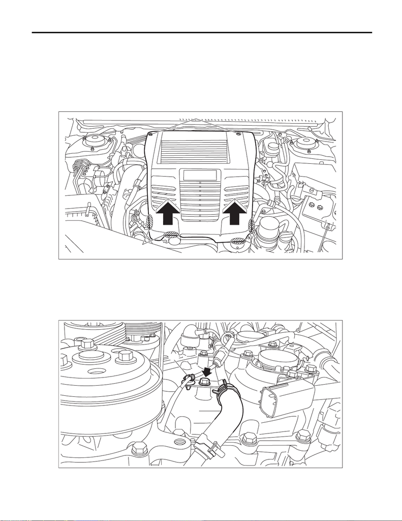

LU(w/o STI)-37

Engine Oil Cooler Pipe

LUBRICATION

8. Engine Oil Cooler Pipe

A: REMOVAL

1. FRONT ENGINE OIL COOLER PIPE

1) Remove the collector cover.

(1) Remove the clips (A).

(2) Hold the shaded area (B) by hand and carefully pull the RH side (C) upward.

(3) Hold the shaded area (D) by hand and carefully pull the LH side (E) upward.

2) Disconnect the ground terminal from battery sensor. <Ref. to NT-5, BATTERY, NOTE, Note.>

3) Drain engine coolant. <Ref. to CO(w/o STI)-13, DRAINING OF ENGINE COOLANT, REPLACEMENT,

Engine Coolant.>

4) Remove the center exhaust pipe. <Ref. to EX(w/o STI)-35, REMOVAL, Center Exhaust Pipe.>

5) Remove the clip (B) which holds the front engine oil cooler hose B (A) and the oil level switch harness from

the front engine oil cooler pipe. Remove the bolt which secures the front engine oil cooler pipe to the chain

cover.

6) Lower the vehicle.

EX-03204

(A)

(B)

(C)

(E)

(D)

LU-03212

(A)

(B)

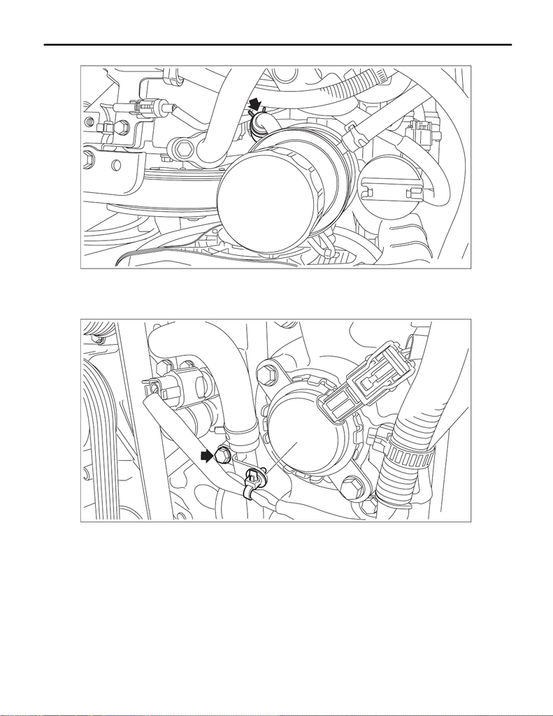

LU(w/o STI)-38

Engine Oil Cooler Pipe

LUBRICATION

7) Disconnect the front engine oil cooler hose A from the engine oil cooler.

8) Remove the clip (A) holding the engine oil temperature sensor harness from the front engine oil cooler

pipe.

9) Remove the bolt which secures the front engine oil cooler pipe to the chain cover. Remove the front engine

oil cooler pipe together with the front engine oil cooler hose A.

10) Remove the front engine oil cooler hose A from the front engine oil cooler pipe.

LU-03040

LU-03041

(A)

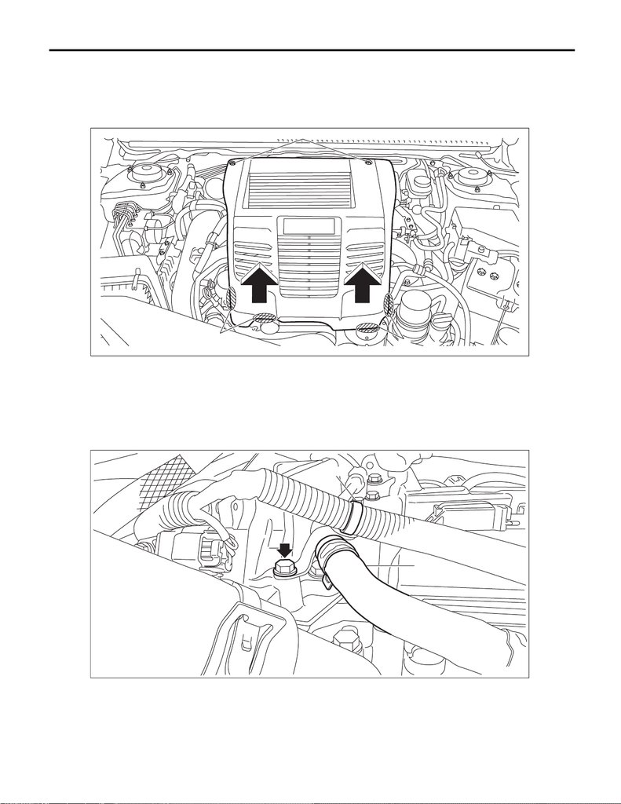

LU(w/o STI)-39

Engine Oil Cooler Pipe

LUBRICATION

2. SIDE ENGINE OIL COOLER PIPE

1) Remove the collector cover.

(1) Remove the clips (A).

(2) Hold the shaded area (B) by hand and carefully pull the RH side (C) upward.

(3) Hold the shaded area (D) by hand and carefully pull the LH side (E) upward.

2) Disconnect the ground terminal from battery sensor. <Ref. to NT-5, BATTERY, NOTE, Note.>

3) Drain engine coolant. <Ref. to CO(w/o STI)-13, DRAINING OF ENGINE COOLANT, REPLACEMENT,

Engine Coolant.>

4) Remove the center exhaust pipe. <Ref. to EX(w/o STI)-35, REMOVAL, Center Exhaust Pipe.>

5) Remove the clip (B) which holds the side engine oil cooler hose B (A) and the rear oxygen sensor harness

from the side engine oil cooler pipe. Remove the bolt which secures the side engine oil cooler pipe to the cam

carrier RH.

6) Lower the vehicle.

EX-03204

(A)

(B)

(C)

(E)

(D)

LU-03214

(A)

(B)

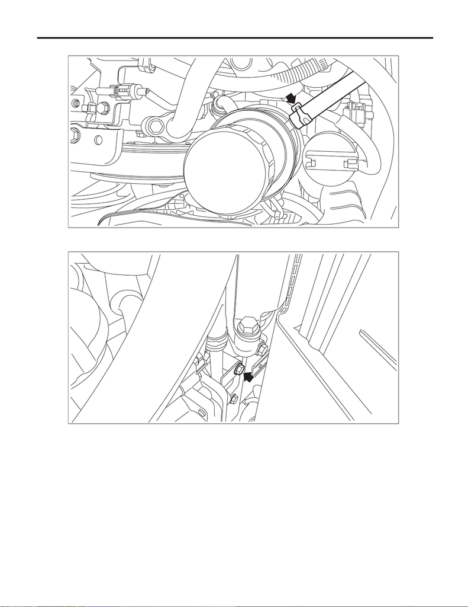

LU(w/o STI)-40

Engine Oil Cooler Pipe

LUBRICATION

7) Disconnect the side engine oil cooler hose A from the engine oil cooler.

8) Remove the bolt which secures the side engine oil cooler pipe to the cam carrier RH. Remove the side en-

gine oil cooler pipe together with the side engine oil cooler hose A.

9) Remove the side engine oil cooler hose A from the side engine oil cooler pipe.

LU-03065

LU-03043

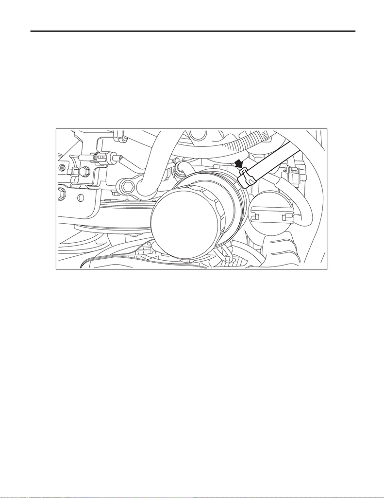

LU(w/o STI)-41

Engine Oil Cooler Pipe

LUBRICATION

B: INSTALLATION

1. FRONT ENGINE OIL COOLER PIPE

Install in the reverse order of removal.

Tightening torque:

6.4 N·m (0.7 kgf-m, 4.7 ft-lb)

2. SIDE ENGINE OIL COOLER PIPE

Install in the reverse order of removal.

NOTE:

When connecting the side engine oil cooler hose A to the engine oil cooler, be careful of the clip direction.

Tightening torque:

6.4 N·m (0.7 kgf-m, 4.7 ft-lb)

C: INSPECTION

1) Check that the engine oil cooler pipes have no deformation, cracks or other damages.

2) Make sure the engine oil cooler hoses are not cracked, damaged or loose.

LU-03065